# Representing Data and Feature Engineering

sources:

- https://github.com/amueller/introduction_to_ml_with_python/blob/master/04-representing-data-feature-engineering.ipynb
- https://www.oreilly.com/library/view/introduction-to-machine/9781449369880/ch04.html
- https://github.com/jakevdp/PythonDataScienceHandbook/blob/master/notebooks/05.04-Feature-Engineering.ipynb

All of the examples we disscussed before assume that you have numerical data in a tidy, [n_samples, n_features] format. In the real world, data rarely comes in such a form. With this in mind, one of the more important steps in using machine learning in practice is **Feature Engineering**: that is the process of using domain knowledge of the data to create features that make machine learning algorithms work.

In this section, we will cover a few common examples of feature engineering tasks:

- feature representation for categorical data, text, and images ...)
- feature engineering:
  - featue selection
  - data transformation
  - data cleaning

## Feature Representation

### Categorical Variables

So far, we assumed that our data comes in as a two-dimensional array of floating point numbers, where each column is a continuous feature that describes the datapoints. For many applications, this is not how the data is collected. A particular common type of feature is **categorical** features, also known as **discrete features**, which areusually not numeric. The distinction between categorical feature and continuous feature is analogous to the distinction between classification and regression - only on theinput side, not the output side

```python
%matplotlib inline
import pandas as pd
import numpy as np
```

```python
# The file has no headers naming the columns, so we pass header=None
# and provide the column names explicitly in "names"
adult_path = "data/adult.csv"
data = pd.read_csv(adult_path, index_col=False, na_values=['#NAME?', '?'])
# For illustration purposes, we only select some of the columns:
data = data[['age', 'workclass', 'education', 'gender', 'hours_per_week',
             'occupation', 'income']]
# IPython.display allows nice output formatting within the Jupyter notebook
display(data.head())
```

|  | age | workclass | education | gender | hours_per_week | occupation | income |
| --- | --- | --- | --- | --- | --- | --- | --- |
| 0 | 39.0 | State-gov | Bachelors | Male | 40 | Adm-clerical | <=50K |
| 1 | 50.0 | Self-emp-not-inc | Bachelors | Male | 13 | Exec-managerial | <=50K |
| 2 | 38.0 | Private | HS-grad | Male | 40 | Handlers-cleaners | <=50K |
| 3 | 53.0 | Private | 11th | NaN | 40 | Handlers-cleaners | <=50K |
| 4 | 28.0 | Private | Bachelors | Female | 40 | Prof-specialty | <=50K |

```python
data.info()
```

```
<class 'pandas.core.frame.DataFrame'>
RangeIndex: 5000 entries, 0 to 4999
Data columns (total 7 columns):
age               4952 non-null float64
workclass         4669 non-null object
education         4943 non-null object
gender            4953 non-null object
hours_per_week    5000 non-null int64
occupation        4669 non-null object
income            5000 non-null object
dtypes: float64(1), int64(1), object(5)
memory usage: 273.5+ KB
```

```python
data = data.dropna()
data.info()
```

```
<class 'pandas.core.frame.DataFrame'>
Int64Index: 4523 entries, 0 to 4999
Data columns (total 7 columns):
age               4523 non-null float64
workclass         4523 non-null object
education         4523 non-null object
gender            4523 non-null object
hours_per_week    4523 non-null int64
occupation        4523 non-null object
income            4523 non-null object
dtypes: float64(1), int64(1), object(5)
memory usage: 282.7+ KB
```

```python
features = data.loc[:,'age':'occupation']
target = data.loc[:,'income']
X = features.values
y = target.values
print("X.shape: {}  y.shape: {}".format(X.shape, y.shape))

print("the first sample:")
print(X[0,:], " ", y[0])
```

```
X.shape: (4523, 6)  y.shape: (4523,)
the first sample:
[39.0 'State-gov' 'Bachelors' 'Male' 40 'Adm-clerical']   <=50K
```

```python
from sklearn.linear_model import LogisticRegression
from sklearn.model_selection import train_test_split

X_train, X_test, y_train, y_test = train_test_split(X, y, random_state=0)
logreg = LogisticRegression().fit(X_train, y_train)

print("Test score: {:.2f}".format(logreg.score(X_test, y_test)))
```

[output not shown]

```python
data.workclass.unique()
```

```
array(['State-gov', 'Self-emp-not-inc', 'Private', 'Federal-gov',
       'Local-gov', 'Self-emp-inc', 'Without-pay'], dtype=object)
```

we need to represent our data in some different way when applying logistic regression

You might be tempted to encode this data with a straightforward numerical mapping:

```python
{'State-gov':1, 'Self-emp-not-inc':2, 'Private':3, 'Federal-gov':4,'Local-gov':5, 'nan':6, 'Self-emp-inc':7, 'Without-pay':8};
```

### One-Hot-Encoding (Dummy variables)

By far the most common way to represent categorical variables is using the one-hot-encoding or one-out-of-N encoding, also known as **dummy variables** The idea behind dummy variables is to replace a categorical variable with one or more new features that can have the **values 0 and 1**.

*How to do that*

- Create dummy features
- Transform a categorical feature into a set of dummy features, each representing a unique category
- In the set of dummy features, 1 indicates that the observation belongs to that category

```python
print(data['income'].value_counts())
```

```
<=50K    3371
>50K     1152
Name: income, dtype: int64
```

```python
# Assign outcome as 0 if income <=50K and as 1 if income >50K
data_T = data.copy()
data_T['income'] = [0 if x == '<=50K' else 1 for x in data_T['income']]
```

```python
data_T.sample(5)
```

|  | age | workclass | education | gender | hours_per_week | occupation | income |
| --- | --- | --- | --- | --- | --- | --- | --- |
| 1831 | 52.0 | Private | HS-grad | Female | 40 | Sales | 0 |
| 667 | 42.0 | Private | HS-grad | Male | 40 | Craft-repair | 1 |
| 1716 | 42.0 | Private | Bachelors | Female | 40 | Adm-clerical | 0 |
| 4116 | 65.0 | Private | Assoc-voc | Male | 20 | Transport-moving | 0 |
| 4643 | 59.0 | Private | 9th | Female | 40 | Other-service | 0 |

or more generally, use *pd.get_dummies*

```python
print("Original features:\n", list(data.columns), "\n")
data_dummies = pd.get_dummies(data)
print("Features after get_dummies:\n", list(data_dummies.columns))
```

[output not shown]

```python
data_dummies.head(n=2)
```

|  | age | hours_per_week | workclass_Federal-gov | workclass_Local-gov | workclass_Private | workclass_Self-emp-inc | workclass_Self-emp-not-inc | workclass_State-gov | workclass_Without-pay | education_10th | ... | occupation_Machine-op-inspct | occupation_Other-service | occupation_Priv-house-serv | occupation_Prof-specialty | occupation_Protective-serv | occupation_Sales | occupation_Tech-support | occupation_Transport-moving | income_<=50K | income_>50K |
| --- | --- | --- | --- | --- | --- | --- | --- | --- | --- | --- | --- | --- | --- | --- | --- | --- | --- | --- | --- | --- | --- |
| 0 | 39.0 | 40 | 0 | 0 | 0 | 0 | 0 | 1 | 0 | 0 | ... | 0 | 0 | 0 | 0 | 0 | 0 | 0 | 0 | 1 | 0 |
| 1 | 50.0 | 13 | 0 | 0 | 0 | 0 | 1 | 0 | 0 | 0 | ... | 0 | 0 | 0 | 0 | 0 | 0 | 0 | 0 | 1 | 0 |

2 rows × 43 columns

```python
# Get only the columns containing features
# that is all columns from 'age' to 'occupation_ Transport-moving'
# This range contains all the features but not the target

features = data_dummies.loc[:, 'age':'occupation_Transport-moving']
# extract NumPy arrays
X = features.values
y = data_dummies['income_>50K'].values
print("X.shape: {}  y.shape: {}".format(X.shape, y.shape))
```

```
X.shape: (4523, 41)  y.shape: (4523,)
```

```python
X_train, X_test, y_train, y_test = train_test_split(X, y, random_state=0)
logreg = LogisticRegression()
logreg.fit(X_train, y_train)
print("Test score: {:.2f}".format(logreg.score(X_test, y_test)))
```

```
Test score: 0.79
```

### Text Features

Another common need in feature engineering is to convert text to a set of representative numerical values.

One of the simplest methods of encoding data is by *word counts*: you take each snippet of text, count the occurrences of each word within it, and put the results in a table.

For example, consider the following set of three phrases:

```python
sample = ['problem of evil',
          'evil queen',
          'horizon problem']
```

For a vectorization of this data based on word count, we could construct a column representing the word "problem," the word "evil," the word "horizon," and so on. While doing this by hand would be possible, the tedium can be avoided by using Scikit-Learn's `CountVectorizer`:

```python
from sklearn.feature_extraction.text import CountVectorizer

vec = CountVectorizer()
X = vec.fit_transform(sample)
X
```

```
<3x5 sparse matrix of type '<class 'numpy.int64'>'
	with 7 stored elements in Compressed Sparse Row format>
```

```python
import pandas as pd
pd.DataFrame(X.toarray(), columns=vec.get_feature_names())
```

|  | evil | horizon | of | problem | queen |
| --- | --- | --- | --- | --- | --- |
| 0 | 1 | 0 | 1 | 1 | 0 |
| 1 | 1 | 0 | 0 | 0 | 1 |
| 2 | 0 | 1 | 0 | 1 | 0 |

There are some issues with this approach, however: the raw word counts lead to features which put too much weight on words that appear very frequently, and this can be sub-optimal in some classification algorithms. One approach to fix this is known as *term frequency-inverse document frequency* (*TF–IDF*) which weights the word counts by a measure of how often they appear in the documents. The syntax for computing these features is similar to the previous example:

```python
from sklearn.feature_extraction.text import TfidfVectorizer
vec = TfidfVectorizer()
X = vec.fit_transform(sample)
pd.DataFrame(X.toarray(), columns=vec.get_feature_names())
```

|  | evil | horizon | of | problem | queen |
| --- | --- | --- | --- | --- | --- |
| 0 | 0.517856 | 0.000000 | 0.680919 | 0.517856 | 0.000000 |
| 1 | 0.605349 | 0.000000 | 0.000000 | 0.000000 | 0.795961 |
| 2 | 0.000000 | 0.795961 | 0.000000 | 0.605349 | 0.000000 |

### Image Features

A comprehensive summary of feature extraction techniques for images is well beyond the scope of this section, but you can find excellent implementations of many of the standard approaches in the [Scikit-Image project](http://scikit-image.org).

## Feature Engineering

### Feature Selection

- In practical ML problem we usually have **too many attributes**.
- Many (perhaps most) of them are **irrelevant or redundant**.
- Adding useless attributes causes the performance of learning schemes **deteriorate**.
- The best way to select relevant attributes is **manually**, based on a deep understanding of the learning problem and what the attributes actually mean
- Automatic methods can be used, called **dimensionality reduction**. It improves the performance also speeds up the algorithms

*Two Types of featue selection*

1. **Scheme-Independent Selection**: make an independent assessment for all the features based on general characteristics of the data, also called filter method.
2. **Scheme-specific selection**: evaluate the subset using the machine learning algorithm that will ultimately be employed for learning, also called wrapper method. The performance of an attribute subset is measured in terms of the learning scheme’s classification performance using just those attributes. The search of attribute subset is computationally expensive, even if we use heuristic search the complexity is about 𝑜(2^𝑘).

Prepare data: load breast cancer dataset the add 50 noise features

```python
from sklearn.datasets import load_breast_cancer
from sklearn.feature_selection import SelectPercentile
from sklearn.model_selection import train_test_split
import numpy as np

cancer = load_breast_cancer()
print(cancer.feature_names)

# get deterministic random numbers
rng = np.random.RandomState(42)
noise = rng.normal(size=(len(cancer.data), 50))
# add noise features to the data
# the first 30 features are from the dataset, the next 50 are noise
X_w_noise = np.hstack([cancer.data, noise])

X_train, X_test, y_train, y_test = train_test_split(
    X_w_noise, cancer.target, random_state=0, test_size=.5)
```

```
['mean radius' 'mean texture' 'mean perimeter' 'mean area'
 'mean smoothness' 'mean compactness' 'mean concavity'
 'mean concave points' 'mean symmetry' 'mean fractal dimension'
 'radius error' 'texture error' 'perimeter error' 'area error'
 'smoothness error' 'compactness error' 'concavity error'
 'concave points error' 'symmetry error' 'fractal dimension error'
 'worst radius' 'worst texture' 'worst perimeter' 'worst area'
 'worst smoothness' 'worst compactness' 'worst concavity'
 'worst concave points' 'worst symmetry' 'worst fractal dimension']
```

#### Removing features with low variance

Simple baseline approach to feature selection. It removes all features whose **variance doesn't meet some threshold**. By default, it removes all **zero-variance** features, i.e. features that have the same value in all samples.

As an example, suppose that we have a dataset with boolean features, and we want to remove all features that are either one or zero (on or off) in more than 80% of the samples. Boolean features are Bernoulli random variables, and the variance of such variables is given by

Var(X) = p(1 - p) so we can select using the threshold .8 * (1 - .8):

```python
from sklearn.feature_selection import VarianceThreshold
sel_var = VarianceThreshold(threshold=(.8 * (1 - .8)))
sel_var.fit(X_train, y_train)
# transform training set
X_train_selected = sel_var.transform(X_train)
```

```
[ True  True  True  True False False False False False False False  True
  True  True False False False False False False  True  True  True  True
 False False False False False False  True  True  True  True  True  True
  True  True  True  True  True  True  True  True  True  True  True  True
  True  True  True  True  True  True  True  True  True  True  True  True
  True  True  True  True  True  True  True  True  True  True  True  True
  True  True  True  True  True  True  True  True]
```

```
([], <a list of 0 Text yticklabel objects>)
```

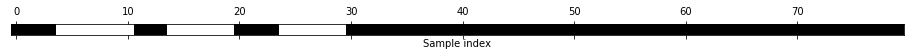

```python
import matplotlib.pyplot as plt
mask = sel.get_support()
print(mask)
# visualize the mask. black is True, white is False
plt.matshow(mask.reshape(1, -1), cmap='gray_r')
plt.xlabel("Sample index")
plt.yticks(())
```

#### Univariate feature selection

Univariate feature selection works by selecting the best features based on **univariate statistical tests**. It can be seen as a preprocessing step to an estimator. Scikit-learn exposes feature selection routines as objects that implement the transform method:

- `SelectKBest` removes all but the k highest scoring features
- `SelectPercentile` removes all but a user-specified highest scoring percentage of features
- using common univariate statistical tests for each feature: false positive rate `SelectFpr`, false discovery rate `SelectFdr`, or family wise error `SelectFwe`.
- `GenericUnivariateSelec`t allows to perform univariate feature selection with a configurable strategy. This allows to select the best univariate selection strategy with hyper-parameter search estimator.

These objects take as input a scoring function that returns univariate scores and p-values (or only scores for `SelectKBest` and `SelectPercentile`):

For regression: `f_regression`, `mutual_info_regression` For classification: `chi2`, `f_classif`, `mutual_info_classif` The methods based on F-test estimate the degree of **linear dependency between two random variables**. On the other hand, mutual information methods can capture any kind of statistical dependency, but being nonparametric, they require more samples for accurate estimation.

```python
# use f_classif (the default) and SelectPercentile to select 50% of features
select = SelectPercentile(percentile=50)
select.fit(X_train, y_train)
# transform training set
X_train_selected = select.transform(X_train)

print("X_train.shape: {}".format(X_train.shape))
print("X_train_selected.shape: {}".format(X_train_selected.shape))
```

```
X_train.shape: (284, 80)
X_train_selected.shape: (284, 40)
```

```
[ True  True  True  True  True  True  True  True  True False  True False
  True  True  True  True  True  True False False  True  True  True  True
  True  True  True  True  True  True False False False  True False  True
 False False  True False False False False  True False False  True False
 False  True False  True False False False False False False  True False
  True False False False False  True False  True False False False False
  True  True False  True False False False False]
```

```
([], <a list of 0 Text yticklabel objects>)
```

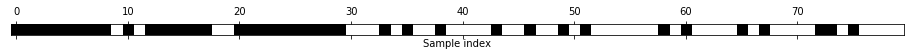

```python
mask = select.get_support()
print(mask)
# visualize the mask. black is True, white is False
plt.matshow(mask.reshape(1, -1), cmap='gray_r')
plt.xlabel("Sample index")
plt.yticks(())
```

```python
from sklearn.linear_model import LogisticRegression

# transform test data
X_test_selected = select.transform(X_test)

#lr = SGDClassifier(loss='log',penalty ='none',max_iter = 5000,shuffle=False,eta0=0.1,learning_rate='constant')
lr = LogisticRegression();
lr.fit(X_train, y_train)
print("Score with all features: {:.3f}".format(lr.score(X_test, y_test)))

lr.fit(X_train_selected, y_train)
print("Score with only selected features: {:.3f}".format(
    lr.score(X_test_selected, y_test)))
```

```
Score with all features: 0.930
Score with only selected features: 0.940
```

#### Model-based Feature Selection

`SelectFromModel` is a meta-transformer that can be used along with any estimator that has a `coef_` or `featureimportances_` attribute after fitting. The features are considered unimportant and removed, if the corresponding `coef_` or `featureimportances_` values are below the provided threshold parameter. Apart from specifying the threshold numerically, there are built-in heuristics for finding a threshold using a string argument. Available heuristics are “mean”, “median” and float multiples of these like “0.1*mean”.

```python
from sklearn.feature_selection import SelectFromModel
from sklearn.ensemble import RandomForestClassifier
select = SelectFromModel(
    RandomForestClassifier(n_estimators=100, random_state=42),
    threshold="median")
```

```python
select.fit(X_train, y_train)
X_train_l1 = select.transform(X_train)
print("X_train.shape: {}".format(X_train.shape))
print("X_train_l1.shape: {}".format(X_train_l1.shape))
```

```
X_train.shape: (284, 80)
X_train_l1.shape: (284, 40)
```

```
([], <a list of 0 Text yticklabel objects>)
```

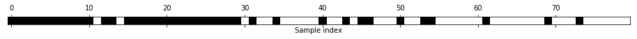

```python
mask = select.get_support()
# visualize the mask. black is True, white is False
plt.matshow(mask.reshape(1, -1), cmap='gray_r')
plt.xlabel("Sample index")
plt.yticks(())
```

```python
X_test_l1 = select.transform(X_test)
score = lr.fit(X_train_l1, y_train).score(X_test_l1, y_test)
print("Test score: {:.3f}".format(score))
```

```
Test score: 0.951
```

#### Recursive feature elimination

Given an external estimator that assigns weights to features (e.g., the coefficients of a linear model), recursive feature elimination (**RFE**) is to select features by **recursively considering smaller and smaller sets of features**. First, the estimator is trained on the initial set of features and weights are assigned to each one of them. Then, features whose absolute weights are the smallest are pruned from the current set features. That procedure is recursively repeated on the pruned set until the desired number of features to select is eventually reached.

`RFECV` performs RFE in a cross-validation loop to find the optimal number of features.

```
([], <a list of 0 Text yticklabel objects>)
```

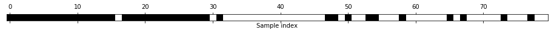

```python
from sklearn.feature_selection import RFE
select = RFE(RandomForestClassifier(n_estimators=100, random_state=42),
             n_features_to_select=40)

select.fit(X_train, y_train)
# visualize the selected features:
mask = select.get_support()
plt.matshow(mask.reshape(1, -1), cmap='gray_r')
plt.xlabel("Sample index")
plt.yticks(())
```

```python
X_train_rfe = select.transform(X_train)
X_test_rfe = select.transform(X_test)
score = lr.fit(X_train_rfe, y_train).score(X_test_rfe, y_test)
print("Test score: {:.3f}".format(score))
```

```
Test score: 0.951
```

## Data Transformation

- A preprocessing steps that **adds, removes, replaces or modifies attributes** to improve the learning process or serve a certain purpose.
- Knowing your data is very important to decide what steps might be helpful.

*Adding polynomial features is a type of data transformation*

Some methods are:

- **Semantic Transformation** define new attributes by applying specified mathematical functions to existing ones.
  - E.g Two date attributes might be subtracted to give a third attribute representing age .
- Transformations suggested by **known properties of the learning algorithm**. If a linear relationship involving two attributes, A and B, is suspected, and the algorithm is only capable of axis-parallel splits the ratio A/B might be defined as a new attribute (e.g. salary per age).
- The transformations are not necessarily mathematical ones but may involve **world knowledge** such as days of the week, or chemical atomic numbers.
- **Reduce several nominal attributes to one by concatenating their values**, producing a single 𝑘_1×𝑘_2-valued attribute from attributes with 𝑘_1and𝑘_2values, respectively.
- Apply a **clustering** procedure to the dataset and then define a new attribute whose value for any given instance is the cluster that contains it using an arbitrary labeling for clusters.
- Apply **probabilistic clustering**, you could augment each instance with its membership probabilities for each cluster, including as many new attributes as there are clusters.
- **Add noise** to data, perhaps to test the robustness of a learning algorithm, take a nominal attribute and change a given percentage of its values.
- **Randomize** the order of instances.
- Produce a random sample of the dataset by **resampling** it (useful for imbalanced datasets)
- Reduce a dataset by **removing all instances that have certain values** for nominal attributes, or numeric values above or below a certain threshold.
- **Remove outliers** by applying a classification method to the dataset and deleting misclassified instances.
- Convert the dataset for sparse to non-sparse or vise versa.
- **Automatic data transformation includes**:
  - **PCA (principle component analysis)**:
    - Principal components analysis transforms the data linearly into a lower dimensional space.
    - We do that by calculating a matrix comprising the eigenvectors of the covariance matrix.
    - Used for data compression and visualization.
    - Computationally expensive.
  - **Random projections**
    - Random projection of the data into a subspace with a predetermined number of dimensions.
    - Performs worse than ones carefully chosen by principal components analysis.
    - far cheaper computationally.

We will discuss some methods of data transformation in scikit learn

### Discretization

The best way to represent data not only depends on the semantics of the data, but also on the kind of model you are using. Two large and very commonly used families of models are linear models and tree-based models (such as decision trees, gradient boosted trees and random forests). Linear models and tree-based models have verydifferent properties when it comes to how they work with different feature represen‐tations.

```python
def make_wave(n_samples=100):
    rnd = np.random.RandomState(42)
    x = rnd.uniform(-3, 3, size=n_samples)
    y_no_noise = (np.sin(4 * x) + x)
    y = (y_no_noise + rnd.normal(size=len(x))) / 2
    return x.reshape(-1, 1), y
```

```
DecisionTreeRegressor error on training set 0.98
LinearRegression error on training set 0.62
```

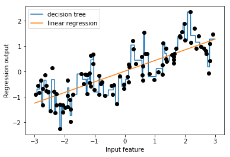

```python
from sklearn.linear_model import LinearRegression
from sklearn.tree import DecisionTreeRegressor

X, y = make_wave(n_samples=100)
# we will use this line to predict on (similar to a test set)
line = np.linspace(-3, 3, 1000, endpoint=False).reshape(-1, 1)

def test_fun(X_train,Line):
    reg = DecisionTreeRegressor(min_samples_split=3).fit(X_train, y)
    print("DecisionTreeRegressor error on training set {:.2f}".format(reg.score(X_train, y)))
    plt.plot(line, reg.predict(Line), label="decision tree")

    reg = LinearRegression().fit(X_train, y)
    print("LinearRegression error on training set {:.2f}".format(reg.score(X_train, y)))
    plt.plot(line, reg.predict(Line), label="linear regression")

    plt.plot(X[:, 0], y, 'o', c='k')
    plt.ylabel("Regression output")
    plt.xlabel("Input feature")
    plt.legend(loc="best")

test_fun(X,line)
```

As you know, linear models can only model linear relationships, which are lines inthe case of a single feature. The decision tree an build a much more complex model ofthe data.

However, this is **strongly dependent on our representation of the data**. One way tomake linear models more powerful on continuous data is to using *binning* (also known as discretization) of the feature *to split it up into multiple features*

```python
bins = np.linspace(-3, 3, 11)
print("bins: {}".format(bins))
```

```
bins: [-3.  -2.4 -1.8 -1.2 -0.6  0.   0.6  1.2  1.8  2.4  3. ]
```

```python
which_bin = np.digitize(X, bins=bins)
print("\nData points:\n", X[:5])
print("\nBin membership for data points:\n", which_bin[:5])
```

```
Data points:
 [[-0.75275929]
 [ 2.70428584]
 [ 1.39196365]
 [ 0.59195091]
 [-2.06388816]]

Bin membership for data points:
 [[ 4]
 [10]
 [ 8]
 [ 6]
 [ 2]]
```

To use a scikit-learn model on this data, we transform this discrete feature to a **one-hot encoding**

```python
from sklearn.preprocessing import OneHotEncoder
# transform using the OneHotEncoder
encoder = OneHotEncoder(sparse=False)
# encoder.fit finds the unique values that appear in which_bin
encoder.fit(which_bin)
# transform creates the one-hot encoding
X_binned = encoder.transform(which_bin)
print(X_binned[:5])
```

```
[[0. 0. 0. 1. 0. 0. 0. 0. 0. 0.]
 [0. 0. 0. 0. 0. 0. 0. 0. 0. 1.]
 [0. 0. 0. 0. 0. 0. 0. 1. 0. 0.]
 [0. 0. 0. 0. 0. 1. 0. 0. 0. 0.]
 [0. 1. 0. 0. 0. 0. 0. 0. 0. 0.]]
```

```python
print("X_binned.shape: {}".format(X_binned.shape))
```

```
X_binned.shape: (100, 10)
```

```
DecisionTreeRegressor error on training set 0.78
LinearRegression error on training set 0.78
```

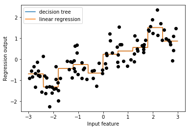

```python
# transform the line as well to test the data o
line_binned = encoder.transform(np.digitize(line, bins=bins))

test_fun(X_binned, line_binned)
```

**More Generally, There are two basic approaches to Descritization**.

- *Unsupervised discretization*: quantize each attribute in the absence of any knowledge of the classes of the instances (like binning as its simplist way).
  - This is the only possibility when dealing with clustering problems.
  - e.g.: equal-frequency binning (histogram Equalization), divides the attribute’s range into a predetermined number of bins based on the distribution of examples along that axis.
- *Supervised discretization*: take the classes into account when discretizing.
  - Entropy-based discretization: split the data recursively to maximize the information gain (Like decision trees).
  - Error-based discretization: split the data to minimize the error when predicting each training instance’s class.

(All are not available in sklearn)

### Scaling

Feature scaling is a method used to **standardize the range** of independent variables or features of data. In data processing, it is also known as data **normalization** and is generally performed during the data preprocessing step

- The **StandardScaler** ensures that for each feature, the mean is zero,and the variance is one, bringing all features to the same magnitude. However, this scaling does not ensure any particular minimum and maximum values for the features.
- The **RobustScaler** works similarly to the StandardScaler in that it ensures statistical properties for each feature that guarantee that they are on the same scale. However, the RobustScaler uses the median and quartiles instead of mean and variance. This makes the RobustScaler ignore data points that are very different from the rest (like measurement errors). These odd data points are also called outliers, and might often lead to trouble for other scaling techniques.
- The **MinMaxScaler** shifts the data such that all features are exactly between 0 and 1.
- The **Normalizer** does a very different kind of rescaling. It scales each data point such that the feature vector has a euclidean length of one. In other words, it projects a data point on the circle (or sphere in the case of higher dimensions) with a radius of 1. This means every data point is scaled by a different number (by the inverse of it’s length). This normalization is often used when only the direction (or angle) of the data matters, not the length of the feature vector.

[figure not shown]

```python
from sklearn.datasets import load_breast_cancer
from sklearn.model_selection import train_test_split
cancer = load_breast_cancer()

X_train, X_test, y_train, y_test = train_test_split(cancer.data, cancer.target,
                                                    random_state=1)
print(X_train.shape)
print(X_test.shape)
```

```
(426, 30)
(143, 30)
```

```python
from sklearn.linear_model import LogisticRegression
lrclf = LogisticRegression()
lrclf.fit(X_train,y_train)
print ("Train set accurecy: {:.2f} ".format(lrclf.score(X_train,y_train)))
print ("Test set accurecy: {:.2f} ".format(lrclf.score(X_test,y_test)))
```

```
Train set accurecy: 0.96
Test set accurecy: 0.95
```

```python
from sklearn.preprocessing import MinMaxScaler


# preprocessing using 0-1 scaling
scaler = MinMaxScaler()
scaler.fit(X_train)
X_train_scaled = scaler.transform(X_train)
X_test_scaled = scaler.transform(X_test)

# learning an LogisticRegression on the scaled training data
lrclf.fit(X_train_scaled, y_train)

# scoring on the scaled test set
print("Scaled train set accuracy: {:.2f}".format(
    lrclf.score(X_train_scaled, y_train)))
print("Scaled test set accuracy: {:.2f}".format(
    lrclf.score(X_test_scaled, y_test)))
```

```
Scaled train set accuracy: 0.96
Scaled test set accuracy: 0.96
```

```python
from sklearn.preprocessing import StandardScaler
scaler = StandardScaler()
scaler.fit(X_train)
X_train_scaled = scaler.transform(X_train)
X_test_scaled = scaler.transform(X_test)

# learning an LogisticRegression on the scaled training data
lrclf.fit(X_train_scaled, y_train)

# scoring on the scaled test set
print("Scaled train set accuracy: {:.2f}".format(
    lrclf.score(X_train_scaled, y_train)))
print("Scaled test set accuracy: {:.2f}".format(
    lrclf.score(X_test_scaled, y_test)))
```

```
Scaled train set accuracy: 0.99
Scaled test set accuracy: 0.98
```

## Data Cleaning

- Poor quality of the data can very much **reduce the quality** of the machine learning algorithm.
- Errors in large databases are extremely **common**.
- Attribute values, and class values too, are frequently unreliable and corrupted.
- **Statisticians** often check data for outliers and remove them manually.

```python
# preparing data
from numpy import nan
X = np.array([[ nan, 0,   3  ],
              [ 3,   7,   9  ],
              [ 3,   5,   2  ],
              [ 4,   nan, 6  ],
              [ 8,   8,   1  ]])
y = np.array([14, 16, -1,  8, -5])
```

### Dealing with missing values:

- Models can not handle missing data
- Simplest solution
  - Remove observations/features that have missing data
- But, **removing** missing data can introduce a lot of issues
  - Data is randomly **missing**: potentially lose a lot of your data
  - Data is non-randomly missing: in addition to losing data, you are also introducing **potential biases**
  - Usually, this is a poor solution
- An alternative solution is to use imputation
  - **Replace** missing value with another value
  - **Strategies**: mean, median, highest frequency value of given feature
  - or use a **machine learning algorithm** to predict the most probable value, i.e. try and predict the probable value in the missing attribute, according to other attributes in the data.

```python
from sklearn.preprocessing import Imputer
imp = Imputer(strategy='mean')
X2 = imp.fit_transform(X)
X2
```

```
array([[4.5, 0. , 3. ],
       [3. , 7. , 9. ],
       [3. , 5. , 2. ],
       [4. , 5. , 6. ],
       [8. , 8. , 1. ]])
```

# Feature Pipelines

With any of the preceding examples, it can quickly become tedious to do the transformations by hand, especially if you wish to string together multiple steps. For example, we might want a processing pipeline that looks something like this:

1. Impute missing values using the mean
2. Transform features to quadratic
3. Fit a linear regression

To streamline this type of processing pipeline, Scikit-Learn provides a `Pipeline` object, which can be used as follows:

```python
from sklearn.pipeline import make_pipeline
from sklearn.preprocessing import PolynomialFeatures

model = make_pipeline(Imputer(strategy='mean'),
                      PolynomialFeatures(degree=2),
                      LinearRegression())
```

This pipeline looks and acts like a standard Scikit-Learn object, and will apply all the specified steps to any input data.

```python
model.fit(X, y)  # X with missing values, from above
print(y)
print(model.predict(X))
```

```
[14 16 -1  8 -5]
[14. 16. -1.  8. -5.]
```